# Homework 4

Ryan Hensley

2023-09-29

**Copyright Kaitlyn Hoffmann, All rights reserved. Not for resale, distribution, or posting to external sites for all content provided.**

## Question 1: Load in the data starbucksmenu.csv as a data frame object called sbux

```r
sbux = read.csv("starbucksmenu.csv")
```

## Question 2: Display the first 8 rows of the data frame object sbux

```r
head(sbux,8)
```

```
##   Beverage_category      Beverage     Beverage_prep Calories Total_Fat_g
## 1            Coffee Brewed Coffee             Short        3         0.1
## 2            Coffee Brewed Coffee              Tall        4         0.1
## 3            Coffee Brewed Coffee            Grande        5         0.1
## 4            Coffee Brewed Coffee             Venti        5         0.1
## 5          Espresso   Caffè Latte Short Nonfat Milk       70         0.1
## 6          Espresso   Caffè Latte           2% Milk      100         3.5
## 7          Espresso   Caffè Latte           Soymilk       70         2.5
## 8          Espresso   Caffè Latte  Tall Nonfat Milk      100         0.2
##   Trans_Fat_g Saturated_Fat_g Sodium_mg Total_Carbs_g Cholesterol_mg Fiber_g
## 1         0.0             0.0         0             5              0       0
## 2         0.0             0.0         0            10              0       0
## 3         0.0             0.0         0            10              0       0
## 4         0.0             0.0         0            10              0       0
## 5         0.1             0.0         5            75             10       0
```

[output cut: 21 more lines]

## Question 3: Display the first 10 rows of the data frame object sbux

```r
head(sbux,10)
```

```
##    Beverage_category      Beverage     Beverage_prep Calories Total_Fat_g
## 1             Coffee Brewed Coffee             Short        3         0.1
## 2             Coffee Brewed Coffee              Tall        4         0.1
## 3             Coffee Brewed Coffee            Grande        5         0.1
## 4             Coffee Brewed Coffee             Venti        5         0.1
## 5           Espresso   Caffè Latte Short Nonfat Milk       70         0.1
## 6           Espresso   Caffè Latte           2% Milk      100         3.5
## 7           Espresso   Caffè Latte           Soymilk       70         2.5
## 8           Espresso   Caffè Latte  Tall Nonfat Milk      100         0.2
## 9           Espresso   Caffè Latte           2% Milk      150         6.0
## 10          Espresso   Caffè Latte           Soymilk      110         4.5
##    Trans_Fat_g Saturated_Fat_g Sodium_mg Total_Carbs_g Cholesterol_mg Fiber_g
## 1          0.0             0.0         0             5              0       0
## 2          0.0             0.0         0            10              0       0
## 3          0.0             0.0         0            10              0       0
```

[output cut: 29 more lines]

## Question 4: Display the last 6 rows of the data frame object sbux

```r
tail(sbux)
```

```
##     Beverage_category                                     Beverage
## 207       Frappuccino Strawberries & Crème (Without Whipped Cream)
## 208       Frappuccino Strawberries & Crème (Without Whipped Cream)
## 209       Frappuccino         Vanilla Bean (Without Whipped Cream)
## 210       Frappuccino         Vanilla Bean (Without Whipped Cream)
## 211       Frappuccino         Vanilla Bean (Without Whipped Cream)
## 212       Frappuccino         Vanilla Bean (Without Whipped Cream)
##          Beverage_prep Calories Total_Fat_g Trans_Fat_g Saturated_Fat_g
## 207         Whole Milk      350         6.0         3.0             0.2
## 208            Soymilk      320         3.2         0.4             0.0
## 209   Tall Nonfat Milk      170         0.1         0.1             0.0
## 210         Whole Milk      200         3.5         2.0             0.1
## 211            Soymilk      180         1.5         0.2             0.0
## 212 Grande Nonfat Milk      240         0.1         0.1             0.0
##     Sodium_mg Total_Carbs_g Cholesterol_mg Fiber_g Sugar_g Protein_g
## 207        15           260             70       0      68         6
## 208         0           250             67       1      64         5
## 209         0           160             39       0      38         4
## 210        10           160             39       0      38         3
## 211         0           160             37       1      35         3
## 212         5           230             56       0      55         5
##     VitaminA_PercDV VitaminC_PercDV Calcium_PercDV Iron_PercDV Caffeine_mg
## 207            0.08            0.08           0.20        0.04           0
## 208            0.06            0.08           0.20        0.10           0
## 209            0.06            0.00           0.10        0.00           0
## 210            0.06            0.00           0.10        0.00           0
## 211            0.04            0.00           0.10        0.06           0
## 212            0.08            0.00           0.15        0.00           0
```

## Question 5: Display the structure of the data frame sbux; look at the data types and make sure they are loaded appropriately

- display the structure (should only be 3 chr characters)
- Bucket the categorical vs numerical variables/columns. Comment your response using # within the chunk.

```r
#str (code)
str(sbux)
```

```
## 'data.frame':    212 obs. of  18 variables:
##  $ Beverage_category: chr  "Coffee" "Coffee" "Coffee" "Coffee" ...
##  $ Beverage         : chr  "Brewed Coffee" "Brewed Coffee" "Brewed Coffee" "Brewed Coffee" ...
##  $ Beverage_prep    : chr  "Short" "Tall" "Grande" "Venti" ...
##  $ Calories         : int  3 4 5 5 70 100 70 100 150 110 ...
##  $ Total_Fat_g      : num  0.1 0.1 0.1 0.1 0.1 3.5 2.5 0.2 6 4.5 ...
##  $ Trans_Fat_g      : num  0 0 0 0 0.1 2 0.4 0.2 3 0.5 ...
##  $ Saturated_Fat_g  : num  0 0 0 0 0 0.1 0 0 0.2 0 ...
##  $ Sodium_mg        : int  0 0 0 0 5 15 0 5 25 0 ...
##  $ Total_Carbs_g    : int  5 10 10 10 75 85 65 120 135 105 ...
##  $ Cholesterol_mg   : int  0 0 0 0 10 10 6 15 15 10 ...
##  $ Fiber_g          : int  0 0 0 0 0 0 1 0 0 1 ...
##  $ Sugar_g          : int  0 0 0 0 9 9 4 14 14 6 ...
##  $ Protein_g        : num  0.3 0.5 1 1 6 6 5 10 10 8 ...
##  $ VitaminA_PercDV  : num  0 0 0 0 0.1 0.1 0.06 0.15 0.15 0.1 ...
##  $ VitaminC_PercDV  : num  0 0 0 0 0 0 0 0 0 0 ...
##  $ Calcium_PercDV   : num  0 0 0 0.02 0.2 0.2 0.2 0.3 0.3 0.3 ...
##  $ Iron_PercDV      : num  0 0 0 0 0 0 0.08 0 0 0.15 ...
##  $ Caffeine_mg      : int  175 260 330 410 75 75 75 75 75 75 ...
```

```r
#categorical: Beverage_category,beverage, beverage_prep
#numerical: Calories,Total_Fat_g,Trans_Fat_g,Saturated_Fat_g,Sodium_mg,Total_Carbs_g,Cholesterol_mg,Fiber_g,Sugar_g, Protein_g,VitaminA_PercDV,VitaminC_PercDV,Calcium_PercDV,Iron_PercDV,Caffeine_mg
```

## Question 6: Display the total number of rows and columns in the data frame sbux

- what does the number of rows represent (conceptually)? Look at the data, see what each row represents. Comment your response using # within the chunk.

```r
#number of rows (code)
nrow(sbux)
```

```
## [1] 212
```

```r
#number of columns (code)
ncol(sbux)
```

```
## [1] 18
```

```r
# what does the number of rows represent (conceptually)?:The number of rows represents the number of orders
```

**ADD THE QUESTIONS BELOW AND A CHUNK FOLLOWING EACH TO THE HW4.RMD**

## Question 7: Basic calculations:

- What is the average Calories from sbux?
- What is the average Caffeine_mg from sbux?
- What are the max Calories from sbux?
- What is the spread/standard deviation (variation) Calories from sbux?
- What is the range for Calories from sbux?

```r
mean(sbux$Calories)
```

```
## [1] 198.0047
```

```r
mean(sbux$Caffeine_mg)
```

```
## [1] 92.26415
```

```r
max(sbux$Calories)
```

```
## [1] 510
```

```r
sd(sbux$Calories)
```

```
## [1] 103.0306
```

```r
max(sbux$Calories) - min(sbux$Calories)
```

```
## [1] 507
```

## Question 8: Display the summary results for the data frame called sbux

- What is the average calories for the drinks? Comment your response using # within the chunk.

```r
summary(sbux)
```

```
##  Beverage_category    Beverage         Beverage_prep         Calories
##  Length:212         Length:212         Length:212         Min.   :  3
##  Class :character   Class :character   Class :character   1st Qu.:120
##  Mode  :character   Mode  :character   Mode  :character   Median :190
##                                                           Mean   :198
##                                                           3rd Qu.:260
##                                                           Max.   :510
##   Total_Fat_g      Trans_Fat_g    Saturated_Fat_g     Sodium_mg
##  Min.   : 0.000   Min.   :0.000   Min.   :0.00000   Min.   : 0.000
##  1st Qu.: 0.200   1st Qu.:0.100   1st Qu.:0.00000   1st Qu.: 0.000
##  Median : 2.500   Median :0.500   Median :0.00000   Median : 5.000
##  Mean   : 3.094   Mean   :1.411   Mean   :0.04009   Mean   : 6.651
##  3rd Qu.: 5.000   3rd Qu.:2.000   3rd Qu.:0.10000   3rd Qu.:10.000
##  Max.   :15.000   Max.   :9.000   Max.   :0.30000   Max.   :40.000
##  Total_Carbs_g   Cholesterol_mg     Fiber_g          Sugar_g
##  Min.   :  0.0   Min.   : 0.00   Min.   :0.0000   Min.   : 0.00
##  1st Qu.: 75.0   1st Qu.:21.00   1st Qu.:0.0000   1st Qu.:18.00
##  Median :132.5   Median :35.00   Median :0.0000   Median :32.00
##  Mean   :137.1   Mean   :36.55   Mean   :0.6179   Mean   :33.89
##  3rd Qu.:182.5   3rd Qu.:50.00   3rd Qu.:1.0000   3rd Qu.:45.00
##  Max.   :340.0   Max.   :90.00   Max.   :4.0000   Max.   :84.00
##    Protein_g      VitaminA_PercDV   VitaminC_PercDV   Calcium_PercDV
##  Min.   : 0.000   Min.   :0.00000   Min.   :0.00000   Min.   :0.0000
##  1st Qu.: 3.000   1st Qu.:0.04000   1st Qu.:0.00000   1st Qu.:0.1000
##  Median : 6.000   Median :0.08000   Median :0.00000   Median :0.2000
##  Mean   : 6.913   Mean   :0.09821   Mean   :0.01193   Mean   :0.2195
##  3rd Qu.:10.000   3rd Qu.:0.15000   3rd Qu.:0.00000   3rd Qu.:0.3000
##  Max.   :19.000   Max.   :0.30000   Max.   :0.20000   Max.   :0.6000
##   Iron_PercDV       Caffeine_mg
##  Min.   :0.00000   Min.   :  0.00
##  1st Qu.:0.00000   1st Qu.: 68.75
##  Median :0.02000   Median : 80.00
##  Mean   :0.07816   Mean   : 92.26
##  3rd Qu.:0.10000   3rd Qu.:145.00
##  Max.   :0.50000   Max.   :410.00
```

```r
#avg is 198
```

## Question 9: Display the summary results for each (BY) Beverage_category separately for column 4 (Calories) only

(points off if not correct view) - Analyze the results - Which beverage category has the highest calories on average (mean)? Comment your response using # within the chunk. - Which beverage category has the lowest calories on average (mean)? Comment your response using # within the chunk. - Which beverage category has the highest calories (max)? Comment your response using # within the chunk.

```r
by(sbux[,4],sbux$Beverage_category,summary)
```

```
## sbux$Beverage_category: Coffee
##    Min. 1st Qu.  Median    Mean 3rd Qu.    Max.
##    3.00    3.75    4.50    4.25    5.00    5.00
## ------------------------------------------------------------
## sbux$Beverage_category: Espresso
##    Min. 1st Qu.  Median    Mean 3rd Qu.    Max.
##       5     110     175     185     250     510
## ------------------------------------------------------------
## sbux$Beverage_category: Frappuccino
##    Min. 1st Qu.  Median    Mean 3rd Qu.    Max.
##    90.0   180.0   230.0   245.1   310.0   460.0
## ------------------------------------------------------------
## sbux$Beverage_category: Iced Coffee
##    Min. 1st Qu.  Median    Mean 3rd Qu.    Max.
##    60.0    87.5   110.0   115.0   137.5   180.0
## ------------------------------------------------------------
## sbux$Beverage_category: Tea
##    Min. 1st Qu.  Median    Mean 3rd Qu.    Max.
##    60.0   130.0   190.0   202.7   260.0   450.0
```

```r
#highest average calories is Frappuccino
#Lowest average calories is Coffee
#Single Max highest calories is Espresso
```

## Question 10: Display a frequency table for Beverage_category from the data frame sbux

- How many Classic Espresso Drinks are available on the menu? Comment your response using # within the chunk.

```r
table(sbux$Beverage_category)
```

```
##
##      Coffee    Espresso Frappuccino Iced Coffee         Tea
##           4          98          61          12          37
```

```r
#98
```

## Question 11: Display a table summarizing the Average (mean) Caffeine_mg by Beverage_category from the data frame

sbux - Which category has the highest overall average mg of caffeine? Comment your response using # within the chunk. - Which category has the lowest overall average mg of caffeine? Comment your response using # within the chunk.

```r
tapply(sbux$Caffeine_mg,sbux$Beverage_category,mean)
```

```
##      Coffee    Espresso Frappuccino Iced Coffee         Tea
##   293.75000   102.39796    79.67213   125.41667    53.64865
```

```r
#Highest AVG Caffeine is Coffee
#Lowest AVG Caffeine is Tea
```

## Question 12:

- Display the summarized standard deviation (sd) Caffeine_mg by Beverage_category for sbux
- Display the summarized average (mean) Calories by Beverage_category for sbux

```r
tapply(sbux$Caffeine_mg,sbux$Beverage_category,sd)
```

```
##      Coffee    Espresso Frappuccino Iced Coffee         Tea
##   100.11452    56.82415    50.14038    58.05398    47.53140
```

```r
tapply(sbux$Calories,sbux$Beverage_category,mean)
```

```
##      Coffee    Espresso Frappuccino Iced Coffee         Tea
##      4.2500    185.0000    245.0820    115.0000    202.7027
```

## Question 13: Display/Plot the distribution for the Calories using the data frame sbux (histogram)

- add a color col=“darkseagreen4”
- add a title main = “Calorie Distribution Table for Starbucks Drinks”

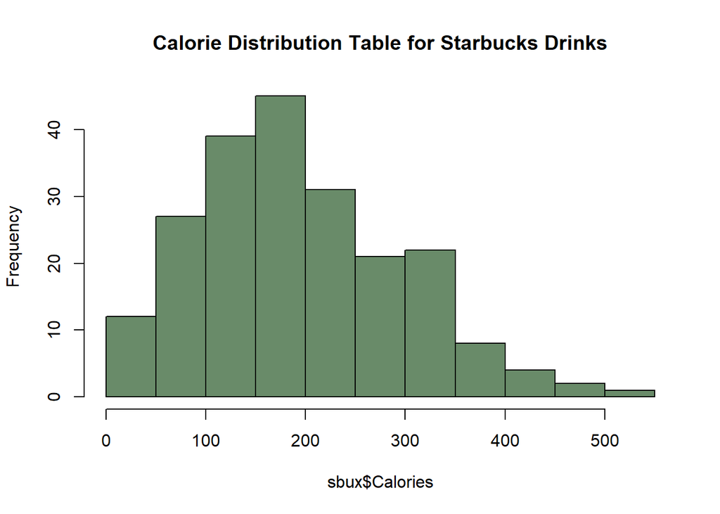

```r
hist(sbux$Calories,main = "Calorie Distribution Table for Starbucks Drinks", col="darkseagreen4")
```

## Question 14: Display a boxplot for Calories from the data frame sbux

- add a color col = “limegreen”
- add a title main = “Calorie Distribution for Starbucks Drinks”
- Based on the output, how many outliers are in the data? Comment your response using # within the chunk.
- Approximately, what is the first quartile? What is the second quartile? Comment your response using # within the chunk.

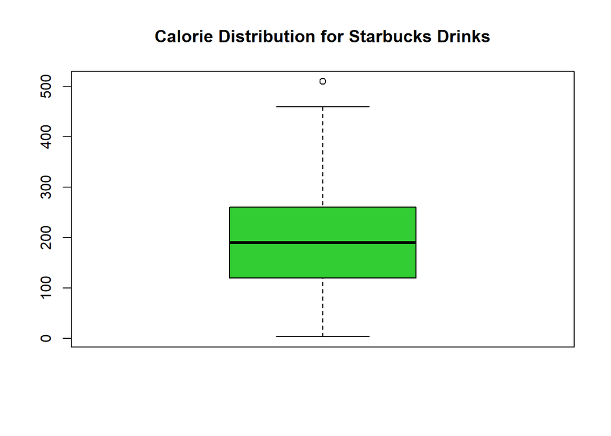

```r
boxplot(sbux$Calories,main = "Calorie Distribution for Starbucks Drinks",col = "limegreen")
```

```r
#1 outlier
# First quartile is 125, second quartile is 200
```

## Question 15: Display a boxplot for Calories by Beverage_category from the data frame sbux

- add a color col = “yellowgreen”
- add a title main = “Calorie Distribution by Beverage Category for Starbucks Drinks”

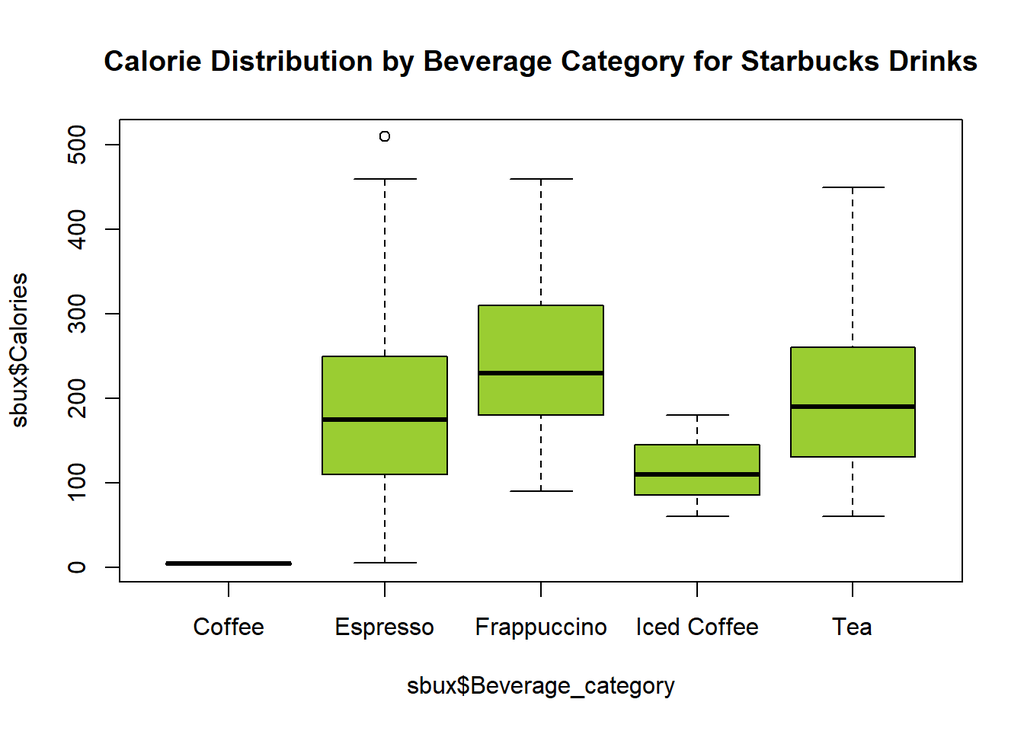

```r
boxplot(sbux$Calories~sbux$Beverage_category,main = "Calorie Distribution by Beverage Category for Starbucks Drinks",col = "yellowgreen")
```

## Question 16: Display a boxplot for Caffeine_mg by Beverage_category from the data frame sbux

- add a color col = “lightgreen”
- add a title main = “Caffeine(mg) Distribution by Beverage Category for Starbucks Drinks”
- Does Coffee or Espresso have higher caffeine? Comment your response using # within the chunk.

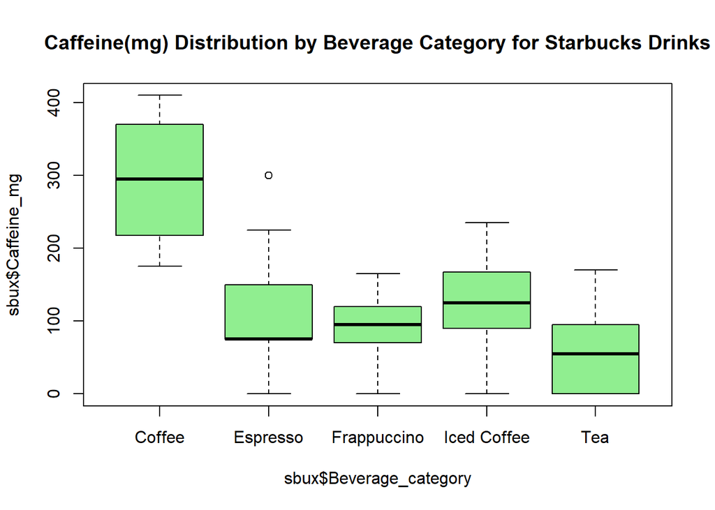

```r
boxplot(sbux$Caffeine_mg~sbux$Beverage_category,main = "Caffeine(mg) Distribution by Beverage Category for Starbucks Drinks",col = "lightgreen")
```

```r
#Coffee
```

## Question 17: Display a scatterplot for Calories (x) and Sugar_g (y) from sbux [Hint: plot(x, y)]

- add a color col = “blue”
- add a title main = “Starbucks: Calories and Sugar”
- Does Calories and Sugar have a positive relationship/trend? Comment your response using # within the chunk. Yes or No

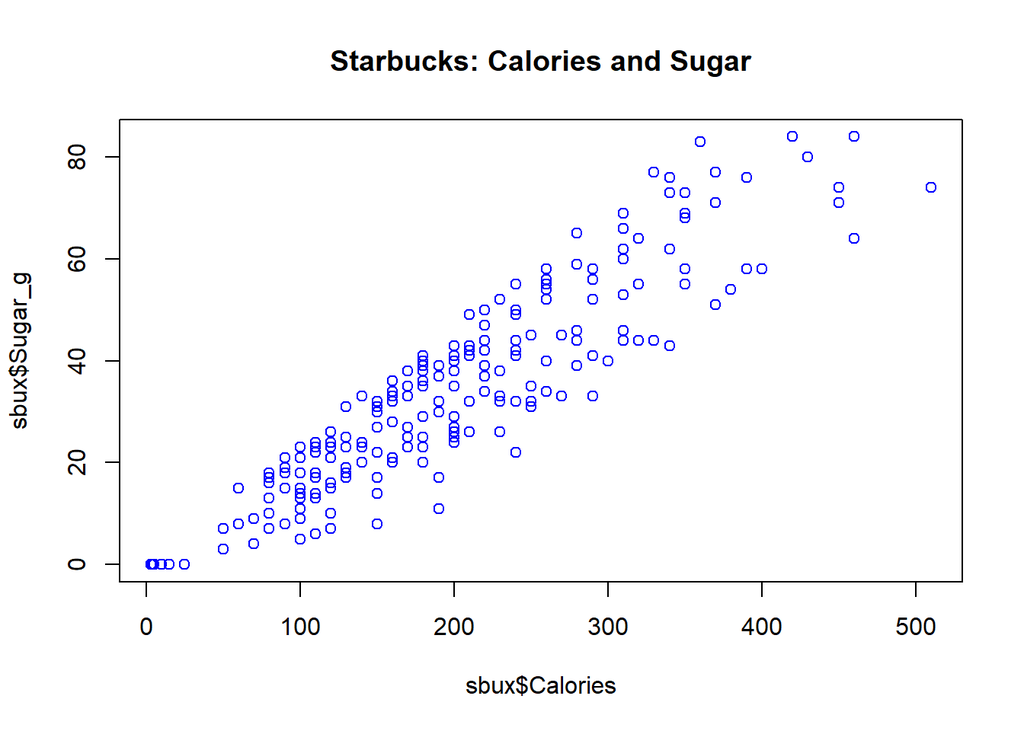

```r
plot(sbux$Calories,sbux$Sugar_g, main = "Starbucks: Calories and Sugar",col = "blue")
```

```r
#Positive
```

## Question 18: Use par(mfrow=c(2,2)) to display the following plots in 2 row 2 columns on the output

- Display a scatterplot for Calories (x) and Sugar_g (y) from sbux (col = “blue”)
- Display a scatterplot for Calories (x) and Total_Carbs_g (y) from sbux (col = “palegreen3”)
- Display a histogram distribution for Calories from sbux (col = “seagreen4”)
- Display a boxplot for Caffeine_mg by Beverage_category from the data frame sbux (col = “limegreen”)

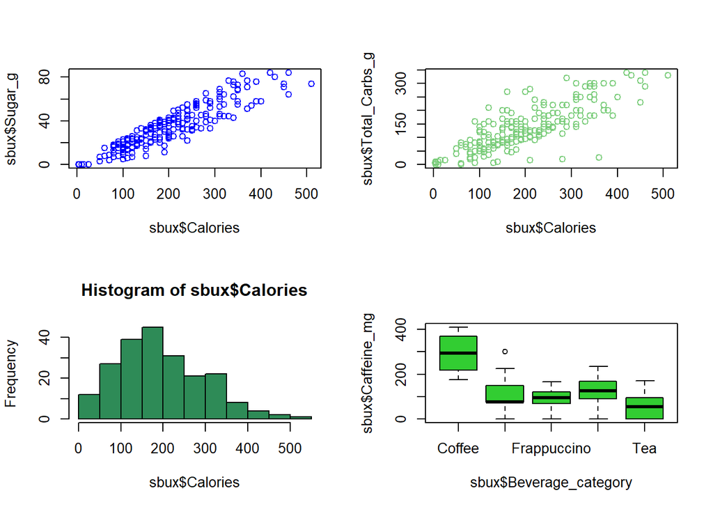

```r
par(mfrow=c(2,2))
plot(sbux$Calories,sbux$Sugar_g,col = "blue")
plot(sbux$Calories,sbux$Total_Carbs_g,col="palegreen3")
hist(sbux$Calories,col="seagreen4")
boxplot(sbux$Caffeine_mg~sbux$Beverage_category,col = "limegreen")
```

### Knit to HTML

**Copyright Kaitlyn Hoffmann, All rights reserved. Not for resale, distribution, or posting to external sites for all content provided.**